# Longitudinal analysis for the pbta-tumor-evolution project and PBTA Cohort

Antonia Chroni chronia@chop.edu and Jo Lynne Rokita rokita@chop.edu for D3B

2023

# Background

### Data used

In this notebook, we are looking into the v12 histologies file (last updates on May 1st, 2023) and subset to the PBTA cohort. We use tumor_descriptor and focus on disease_stages: Diagnosis, Progressive, Recurrence, and Deceased.

### Note

The colors in the plots do not match the ones of the PBTA cohort yet. —TO DO—

### Usage

This notebook is intended to be run via the command line from the top directory of the repository as follows:

```
Rscript -e "rmarkdown::render('analyses/01_sample_distribution_analysis/01-tumor-descriptor-and-assay-count-plot.Rmd', clean = TRUE)"
```

# Set up

```r
suppressPackageStartupMessages({
  library(tidyverse)
  library(ggplot2)
  library(flextable)
  library(RColorBrewer) # to discard later
})
```

## Directories and File Inputs/Outputs

```r
# Detect the ".git" folder -- this will be in the project root directory.
# Use this as the root directory to ensure proper sourcing of functions no
# matter where this is called from
root_dir <- rprojroot::find_root(rprojroot::has_dir(".git"))
setwd(root_dir)


# File path to input directory
input_dir <-
  file.path(root_dir, "input")


# Inputs
input_metadata <- file.path(input_dir, "histologies.tsv")
input_cols <- file.path(input_dir, "PBTA-germline-histology-groups-plot-mapping.tsv")


# File path to results directory
results_dir <-
  file.path(root_dir, "results")
if (!dir.exists(results_dir)) {
  dir.create(results_dir)
}


# File path to plots directory
# plots_dir <-
#   file.path(root_dir, "plots")
# if (!dir.exists(plots_dir)) {
#   dir.create(plots_dir)
# }


# Outputs
output_PBTA_filter <- file.path(results_dir, "data_by_cohort_PBTA_filter.tsv")
output_PBTA_filter_count <- file.path(results_dir, "data_by_cohort_PBTA_filter_count.tsv")
output_Diagnosis_paired <- file.path(results_dir, "Diagnosis_paired.tsv")
output_Diagnosis_paired_dup <- file.path(results_dir, "Diagnosis_paired_dup.tsv")

output_Diagnosis_paired_cancer_group <- file.path(results_dir, "Diagnosis_paired_cancer_group.tsv")
output_Diagnosis_paired_cancer_group_duplicates <- file.path(results_dir, "Diagnosis_paired_cancer_group-duplicates.tsv")


# to add this later
# source publication theme
# source(file.path(root_dir, "figures", "theme.R"))
```

## Load data

```r
# Inputs
## Read in metadata
histologies <- readr::read_tsv(input_metadata, guess_max = 100000, show_col_types = FALSE)
# dim(data)

# Read table with colors per histology
cols <- readr::read_tsv(input_cols, guess_max = 100000, show_col_types = FALSE) # Load plotting colors

# Add colors palette to the histologies file
hist_cols <- histologies %>% left_join(cols, by=c('cancer_group','broad_histology'))  #to merge tables
# This is the tidyverse method. Try not to name variables the same as a function's name - that may cause coding errors downstream.


# to discard when add the col palette for PBTA cohort
mypalette <- brewer.pal(12,"Paired") # colorblindFriendly = TRUE
col5 <- colorRampPalette(mypalette)(5)
col9 <- colorRampPalette(mypalette)(9)
```

# Process Data

All tumor samples have matched normal samples. We need to filter normal samples out for further analysis. We are using “pathology_diagnosis” instead of “sample_type”. This way we discard normal samples (as shown in “sample_type”) in addition to undiagnosed tumor samples. Also, we will discard Derived Cell Line, PDX from “composition”.

```r
tumor_df <- hist_cols  %>%
   filter(cohort == "PBTA",
          !is.na(pathology_diagnosis),
          !composition %in% c("Derived Cell Line", "PDX")) %>%
         # !is.na(cancer_group) # Discard NAs in cancer type
   mutate(tumor_descriptor = ifelse(sample_id == "C4106355-Tumor", "Recurrence", # to be updated in v13 as "Recurrence"
                            ifelse(sample_id == "C4113612-Tumor", "Diagnosis", # to be updated in v13 as "Initial CNS Tumor"
                            ifelse(tumor_descriptor == "Primary Tumor", "Diagnosis",
                            ifelse(tumor_descriptor == "Initial CNS Tumor", "Diagnosis",
                            ifelse(tumor_descriptor == 'Progressive Disease Post-Mortem', 'Deceased',
                                          tumor_descriptor))))))

print (tumor_df %>% count(tumor_descriptor))
```

| tumor_descriptor | n |
| --- | --- |
| Deceased | 644 |
| Diagnosis | 4428 |
| Metastatic | 3 |
| Not Reported | 2 |
| Progressive | 704 |
| Recurrence | 523 |
| Residual | 4 |
| Second Malignancy | 70 |
| Unavailable | 9 |
| NA | 10 |

```r
# Note
# The following samples (sample_id) are marked as Not Reported tumor_descriptor: 7316UP-3705, C4106355-Tumor, and C4113612-Tumor
# Jo Lynne found the following status for 2/3 in the data warehouse:
# C4106355-Tumor = Recurrence
# C4113612-Tumor = Initial CNS Tumor
# 7316UP-3705 = Not Reported
# manually annotate them here and these will be updated in the v13 - then discard that part of the code
# For now, you can leave this - we can fix the plot colors later - it might be that we have a longitudinal sample which comes from a benign tumor - we can possibly remove these later, but it would be good to get a source of truth for what our entire cohort looks like first before removing data,

# Save tumor_df after filter
write_tsv(tumor_df, path = output_PBTA_filter)

count1 <- tumor_df %>%
          group_by(cohort_participant_id, Kids_First_Participant_ID,
                 experimental_strategy, sample_type, tumor_descriptor, primary_site,
                 age_at_diagnosis_days, age_last_update_days, age_at_chemo_start, age_at_radiation_start,
                 pathology_diagnosis, cancer_group, broad_histology) %>%
          dplyr::count(cancer_group)

write_tsv(count1, output_PBTA_filter_count)
```

# Plots

## All assays

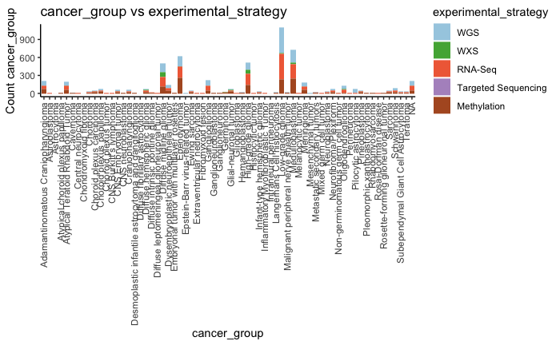

```r
count1$experimental_strategy <- factor(x = count1$experimental_strategy, levels = c("WGS", "WXS", "RNA-Seq", "Targeted Sequencing", "Methylation"))

p <- ggplot(count1, aes(x=cancer_group, fill=experimental_strategy))+
        geom_bar()+
        scale_fill_manual(values=col5) +
        theme_classic()+
        ylab("Count cancer_group") +
        ggtitle("cancer_group vs experimental_strategy") +
        guides(color=guide_legend(override.aes=list(size=3))) +
        theme(axis.text.x = element_text(angle = 90, vjust = 0.5, hjust = 1))
        print(p)
```

```r
#ggsave("Barplot_cancer_group_experimental_strategy_PBTA.pdf", plot=p, path=plots_dir, device="pdf", height=7, width=10)
```

## Paired genomic, transcriptomic assays

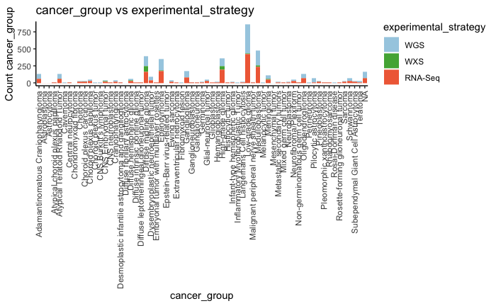

```r
count <- count1 %>% filter(experimental_strategy %in% c("WGS", "WXS", "RNA-Seq")) # Excluded: "Targeted Sequencing", Methylation
count$experimental_strategy <- factor(x = count$experimental_strategy, levels = c("WGS", "WXS", "RNA-Seq"))

p <- ggplot(count, aes(x=cancer_group, fill=experimental_strategy))+
        geom_bar()+
        scale_fill_manual(values=col5) + #scale_fill_manual(values=c(tumor_df$plot_group_hex))
        theme_classic()+
        ylab("Count cancer_group") +
        ggtitle("cancer_group vs experimental_strategy") +
        guides(color=guide_legend(override.aes=list(size=3))) +
        theme(axis.text.x = element_text(angle = 90, vjust = 0.5, hjust = 1))
        print(p)
```

```r
#ggsave("Barplot_cancer_group_experimental_strategy_PBTA_matched_DNA-RNA.pdf", plot=p, path=plots_dir, device="pdf", height=7, width=10)
```

## By cancer_group - all disease stages

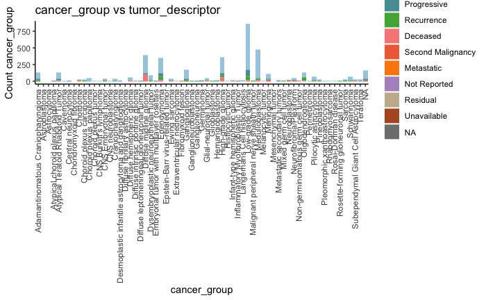

```r
count$tumor_descriptor <- factor(x = count$tumor_descriptor, levels = c("Diagnosis", "Progressive", "Recurrence", "Deceased", "Second Malignancy", "Metastatic", "Not Reported", "Residual", "Unavailable"))


p <- ggplot(count, aes(x=cancer_group, fill=tumor_descriptor))+
        geom_bar()+
        scale_fill_manual(values=col9) +
        theme_classic()+
        ylab("Count cancer_group") +
        ggtitle("cancer_group vs tumor_descriptor") +
        guides(color=guide_legend(override.aes=list(size=3))) +
        theme(axis.text.x = element_text(angle = 90, vjust = 0.5, hjust = 1))
        print(p)
```

```r
#ggsave("Barplot_cancer_group_tumor_descriptor_PBTA_matched_DNA-RNA.pdf", plot=p, path=plots_dir, device="pdf", height=7, width=10)
```

# Summary

In the following section, we will provide summary table across different disease stages, histologies, and patients samples.

## Number of each assay

First, we’ll examine how many of each type of assay we have (tumors only). This information is stored in the experimental_strategy column.

```r
tumor_df %>%
  group_by(experimental_strategy) %>%
  tally() %>%
  arrange(desc(n)) %>%
  regulartable() %>%
  fontsize(size = 12, part = "all")
```

| experimental_strategy | n |
| --- | --- |
| WGS | 2,181 |
| RNA-Seq | 2,129 |
| Methylation | 1,854 |
| WXS | 232 |
| Targeted Sequencing | 1 |

```r
NA
```

# Diagnosis vs. any other point in time (recurrence, progressive etc)

We’ll look at the breakdown of the tumor_descriptor column, separating the genomic assays from transcriptomic assays.

```r
tumor_descriptor_df <- tumor_df %>%
  select(Kids_First_Participant_ID,
         experimental_strategy,
         tumor_descriptor,
         cancer_group) %>%
  arrange(Kids_First_Participant_ID)
```

## Genomic assays

Setting aside the Panel sample for the moment and only looking at WXS and WGS assays. We’re collapsing the different values in tumor_descriptor to form a single descriptor when there are multiple types of tumors from the same individual.

```r
genomic_df <- tumor_descriptor_df %>%
  filter(experimental_strategy %in% c("WGS", "WXS")) %>%
  group_by(Kids_First_Participant_ID) %>%
  summarize(descriptors = paste(sort(unique(tumor_descriptor)),
                                collapse = ", "),
            experimental_strategy = paste(sort(unique(experimental_strategy)),
                                          collapse = ", "),
            cancer_group = paste(sort(unique(cancer_group)),
                                          collapse = ", "))

genomic_df %>%
  group_by(descriptors) %>%
  tally() %>%
  arrange(desc(n)) %>%
  regulartable() %>%
  fontsize(size = 12, part = "all")
```

| descriptors | n |
| --- | --- |
| Diagnosis | 1,505 |
| Progressive | 153 |
| Recurrence | 116 |
| Deceased | 81 |
| Diagnosis, Progressive | 45 |
| Diagnosis, Recurrence | 27 |
| Deceased, Diagnosis | 17 |
| Second Malignancy | 15 |
| Progressive, Recurrence | 6 |
| Diagnosis, Second Malignancy | 5 |
| Diagnosis, Progressive, Recurrence | 4 |
| Deceased, Diagnosis, Recurrence | 3 |
| Deceased, Progressive | 3 |
| Deceased, Progressive, Recurrence | 3 |
|  | 2 |
| Recurrence, Second Malignancy | 2 |
| Residual | 2 |
| Unavailable | 2 |
| Deceased, Diagnosis, Progressive | 1 |
| Deceased, Diagnosis, Progressive, Recurrence | 1 |
| Deceased, Recurrence | 1 |
| Diagnosis, Unavailable | 1 |
| Metastatic | 1 |
| Not Reported | 1 |

```r
NA
```

## Transcriptomic assays

Looking only at RNA-seq samples and performing the same collapsing of the tumor_descriptor column.

```r
transcriptomic_df <- tumor_descriptor_df %>%
  filter(experimental_strategy == "RNA-Seq") %>%
  group_by(Kids_First_Participant_ID) %>%
  summarize(descriptors = paste(sort(unique(tumor_descriptor)),
                                collapse = ", "),
            experimental_strategy = unique(experimental_strategy),
            cancer_group = paste(sort(unique(cancer_group)),
                                          collapse = ", "))

transcriptomic_df %>%
  group_by(descriptors) %>%
  tally() %>%
  arrange(desc(n)) %>%
  regulartable() %>%
  fontsize(size = 12, part = "all")
```

| descriptors | n |
| --- | --- |
| Diagnosis | 1,355 |
| Progressive | 143 |
| Recurrence | 126 |
| Deceased | 70 |
| Diagnosis, Progressive | 43 |
| Diagnosis, Recurrence | 31 |
| Deceased, Diagnosis | 21 |
| Second Malignancy | 14 |
| Progressive, Recurrence | 5 |
| Diagnosis, Progressive, Recurrence | 4 |
|  | 3 |
| Deceased, Progressive, Recurrence | 3 |
| Deceased, Recurrence | 3 |
| Recurrence, Second Malignancy | 3 |
| Deceased, Progressive | 2 |
| Diagnosis, Second Malignancy | 2 |
| Metastatic | 2 |
| Residual | 2 |
| Deceased, Diagnosis, Progressive | 1 |
| Deceased, Diagnosis, Recurrence | 1 |
| Deceased, Second Malignancy | 1 |
| Diagnosis, Recurrence, Second Malignancy | 1 |
| Diagnosis, Unavailable | 1 |
| Not Reported | 1 |
| Unavailable | 1 |

## Paired genomic, transcriptomic assays

How many participants have paired genomic and transcriptomic samples for the same tumor_descriptor values?

```r
# if we perform a full join here using the Kids_First_Participant_ID and descriptors, we
# will get NAs in columns where pairs don't exist and can use this information
# to count
paired_df <-
  full_join(genomic_df, transcriptomic_df,
                   by = c("cancer_group", "Kids_First_Participant_ID", "descriptors"))
```

### All time points

Count the examples where all time points have both kinds of assays.

```r
# no NAs = both kinds of assays are present
paired_df %>%
  filter(complete.cases(.)) %>%
  group_by(descriptors) %>%
  tally() %>%
  arrange(desc(n)) %>%
  regulartable() %>%
  fontsize(size = 12, part="all")
```

| descriptors | n |
| --- | --- |
| Diagnosis | 1,181 |
| Progressive | 106 |
| Recurrence | 91 |
| Deceased | 46 |
| Diagnosis, Progressive | 29 |
| Diagnosis, Recurrence | 18 |
| Second Malignancy | 9 |
| Deceased, Diagnosis | 8 |
| Progressive, Recurrence | 4 |
| Deceased, Progressive, Recurrence | 3 |
|  | 2 |
| Diagnosis, Progressive, Recurrence | 2 |
| Diagnosis, Second Malignancy | 2 |
| Recurrence, Second Malignancy | 2 |
| Residual | 2 |
| Deceased, Diagnosis, Recurrence | 1 |
| Deceased, Progressive | 1 |
| Deceased, Recurrence | 1 |
| Diagnosis, Unavailable | 1 |
| Metastatic | 1 |
| Not Reported | 1 |
| Unavailable | 1 |

### Diagnosis paired with another point in time

```r
Diagnosis_paired <- paired_df  %>%
  filter(descriptors != "Diagnosis")  %>%
  filter(grepl("Diagnosis", descriptors))

# Save Diagnosis_paired
write_tsv(Diagnosis_paired, path = output_Diagnosis_paired)

Diagnosis_paired <- Diagnosis_paired[with(Diagnosis_paired, order(descriptors, cancer_group)), ]


Diagnosis_paired %>%
  regulartable() %>%
  fontsize(size = 12, part = "all")
```

| Kids_First_Participant_ID | descriptors | experimental_strategy.x | cancer_group | experimental_strategy.y |
| --- | --- | --- | --- | --- |
| PT_3KM9W8S8 | Deceased, Diagnosis | WGS | Atypical Teratoid Rhabdoid Tumor | RNA-Seq |
| PT_RJ1TJ2KH | Deceased, Diagnosis | WGS | Atypical Teratoid Rhabdoid Tumor | RNA-Seq |
| PT_4W0BP7F3 | Deceased, Diagnosis |  | Atypical Teratoid Rhabdoid Tumor | RNA-Seq |
| PT_75HRTX4S | Deceased, Diagnosis | WGS | Chordoma |  |
| PT_AP658JQV | Deceased, Diagnosis |  | Diffuse hemispheric glioma | RNA-Seq |
| PT_R4T1V1K4 | Deceased, Diagnosis |  | Diffuse intrinsic pontine glioma, Diffuse midline glioma | RNA-Seq |
| PT_19GCSK2S | Deceased, Diagnosis | WGS | Diffuse midline glioma | RNA-Seq |
| PT_5NS35B66 | Deceased, Diagnosis | WGS | Diffuse midline glioma |  |
| PT_FA2F3HQG | Deceased, Diagnosis | WGS | Diffuse midline glioma |  |
| PT_GTHZF21E | Deceased, Diagnosis | WGS | Diffuse midline glioma |  |
| PT_KTRJ8TFY | Deceased, Diagnosis | WGS, WXS | Diffuse midline glioma |  |
| PT_MNSEJCDM | Deceased, Diagnosis | WGS | Diffuse midline glioma |  |
| PT_PR4YBBH3 | Deceased, Diagnosis | WGS | Diffuse midline glioma | RNA-Seq |
| PT_59D00MBQ | Deceased, Diagnosis |  | Diffuse midline glioma | RNA-Seq |
| PT_7DTGJYA7 | Deceased, Diagnosis |  | Diffuse midline glioma | RNA-Seq |
| PT_K1YK24PP | Deceased, Diagnosis |  | Diffuse midline glioma | RNA-Seq |
| PT_VCD0W8HG | Deceased, Diagnosis |  | Diffuse midline glioma | RNA-Seq |
| PT_MKDQZ17N | Deceased, Diagnosis |  | Ependymoma | RNA-Seq |
| PT_37B5JRP1 | Deceased, Diagnosis | WGS | High-grade glioma | RNA-Seq |
| PT_394ZA6P7 | Deceased, Diagnosis | WGS | High-grade glioma | RNA-Seq |
| PT_3CHB9PK5 | Deceased, Diagnosis | WGS | High-grade glioma | RNA-Seq |
| PT_KBFM551M | Deceased, Diagnosis | WGS, WXS | High-grade glioma |  |
| PT_CSZ9QA1N | Deceased, Diagnosis |  | High-grade glioma | RNA-Seq |
| PT_S0Q27J13 | Deceased, Diagnosis |  | High-grade glioma | RNA-Seq |
| PT_Z4BF2NSB | Deceased, Diagnosis |  | High-grade glioma | RNA-Seq |
| PT_SY6W6B0Z | Deceased, Diagnosis |  | Malignant peripheral nerve sheath tumor | RNA-Seq |
| PT_23NZGSRJ | Deceased, Diagnosis | WGS | Medulloblastoma | RNA-Seq |
| PT_CXT81GRM | Deceased, Diagnosis | WGS | Medulloblastoma |  |
| PT_NZ85YSJ1 | Deceased, Diagnosis | WGS | Medulloblastoma |  |
| PT_H3WWDMW9 | Deceased, Diagnosis |  | Medulloblastoma | RNA-Seq |

[output cut: 118 more lines]

### No RNA-seq

If the experimental_strategy.y column has an NA, RNA-seq is missing for that participant-descriptors pair.

```r
paired_df %>%
  filter(is.na(experimental_strategy.y)) %>%
  group_by(descriptors) %>%
  tally() %>%
  regulartable() %>%
  fontsize(size = 12, part = "all")
```

| descriptors | n |
| --- | --- |
| Deceased | 35 |
| Deceased, Diagnosis | 9 |
| Deceased, Diagnosis, Progressive | 1 |
| Deceased, Diagnosis, Progressive, Recurrence | 1 |
| Deceased, Diagnosis, Recurrence | 2 |
| Deceased, Progressive | 2 |
| Diagnosis | 324 |
| Diagnosis, Progressive | 16 |
| Diagnosis, Progressive, Recurrence | 2 |
| Diagnosis, Recurrence | 9 |
| Diagnosis, Second Malignancy | 3 |
| Progressive | 47 |
| Progressive, Recurrence | 2 |
| Recurrence | 25 |
| Second Malignancy | 6 |
| Unavailable | 1 |

### No WXS or WGS

If the experimental_strategy.x column has an NA, there is no WGS or WXS for that participant-descriptors pair.

```r
paired_df %>%
  filter(is.na(experimental_strategy.x)) %>%
  group_by(descriptors) %>%
  tally() %>%
  regulartable() %>%
  fontsize(size = 12, part = "all")
```

| descriptors | n |
| --- | --- |
|  | 1 |
| Deceased | 24 |
| Deceased, Diagnosis | 13 |
| Deceased, Diagnosis, Progressive | 1 |
| Deceased, Progressive | 1 |
| Deceased, Recurrence | 2 |
| Deceased, Second Malignancy | 1 |
| Diagnosis | 174 |
| Diagnosis, Progressive | 14 |
| Diagnosis, Progressive, Recurrence | 2 |
| Diagnosis, Recurrence | 13 |
| Diagnosis, Recurrence, Second Malignancy | 1 |
| Metastatic | 1 |
| Progressive | 37 |
| Progressive, Recurrence | 1 |
| Recurrence | 35 |
| Recurrence, Second Malignancy | 1 |
| Second Malignancy | 5 |

### Duplicate participant IDs

There are cases where one timepoint (e.g., tumor_descriptor value) is missing from one kind of assay but not the other. This will show up as duplicated values in the Kids_First_Participant_ID column.

```r
ids_with_dups <- paired_df %>%
  filter(duplicated(Kids_First_Participant_ID)) %>%
  pull(Kids_First_Participant_ID)

Diagnosis_paired_dup <- paired_df %>%
  filter(Kids_First_Participant_ID %in% ids_with_dups) %>%
  arrange(Kids_First_Participant_ID)

# Save Diagnosis_paired
write_tsv(Diagnosis_paired_dup, path = output_Diagnosis_paired_dup)

Diagnosis_paired_dup %>%
  regulartable() %>%
  fontsize(size = 12, part = "all")
```

| Kids_First_Participant_ID | descriptors | experimental_strategy.x | cancer_group | experimental_strategy.y |
| --- | --- | --- | --- | --- |
| PT_0MHKP408 | Diagnosis | WGS | Low-grade glioma |  |
| PT_0MHKP408 | Diagnosis, Progressive |  | Low-grade glioma, Pilocytic astrocytoma | RNA-Seq |
| PT_164RNWTT | Diagnosis | WGS | Ependymoma |  |
| PT_164RNWTT | Diagnosis, Progressive |  | Ependymoma | RNA-Seq |
| PT_26V72ZXB | Diagnosis | WGS | Medulloblastoma |  |
| PT_26V72ZXB | Diagnosis, Progressive |  | Medulloblastoma | RNA-Seq |
| PT_2MZPGZN1 | Diagnosis, Recurrence | WGS | Low-grade glioma |  |
| PT_2MZPGZN1 | Diagnosis |  | Low-grade glioma | RNA-Seq |
| PT_30EX0QAT | Progressive | WGS | Atypical Teratoid Rhabdoid Tumor |  |
| PT_30EX0QAT | Diagnosis |  | Atypical Teratoid Rhabdoid Tumor | RNA-Seq |
| PT_3D74J8RZ | Progressive | WGS | Meningioma |  |
| PT_3D74J8RZ | Progressive |  | Meningioma, Schwannoma | RNA-Seq |
| PT_3P3HARZ2 | Diagnosis, Progressive | WGS | Low-grade glioma, Pilocytic astrocytoma |  |
| PT_3P3HARZ2 | Progressive |  | Low-grade glioma | RNA-Seq |
| PT_3WA7SBQ6 | Diagnosis | WGS | Choroid plexus carcinoma |  |
| PT_3WA7SBQ6 | Diagnosis, Recurrence |  | Choroid plexus carcinoma | RNA-Seq |
| PT_59D00MBQ | Diagnosis | WGS | Diffuse midline glioma |  |
| PT_59D00MBQ | Deceased, Diagnosis |  | Diffuse midline glioma | RNA-Seq |
| PT_5CYJ3NZ9 | Diagnosis, Progressive | WGS | CNS Embryonal tumor |  |
| PT_5CYJ3NZ9 | Progressive |  | CNS Embryonal tumor | RNA-Seq |
| PT_67R1AF5R | Diagnosis | WGS | Ependymoma |  |
| PT_67R1AF5R | Diagnosis, Recurrence |  | Ependymoma | RNA-Seq |
| PT_6N825561 | Deceased, Progressive | WGS | Atypical Teratoid Rhabdoid Tumor |  |
| PT_6N825561 | Deceased |  | Atypical Teratoid Rhabdoid Tumor | RNA-Seq |
| PT_6Q0NPVP3 | Diagnosis | WGS | Ganglioglioma |  |
| PT_6Q0NPVP3 | Diagnosis, Recurrence |  | Ganglioglioma | RNA-Seq |
| PT_7HGY5W67 | Progressive, Recurrence | WGS | CNS Embryonal tumor, Glial-neuronal tumor |  |
| PT_7HGY5W67 | Recurrence |  | Glial-neuronal tumor | RNA-Seq |
| PT_7WYPEC3Q | Diagnosis, Progressive | WGS | Medulloblastoma |  |
| PT_7WYPEC3Q | Diagnosis |  | Medulloblastoma | RNA-Seq |

[output cut: 122 more lines]

### Cohorts with low survival

Let’s estimate how many patient samples we have with Diagnosis paired with another point in time. We will do this for cohorts with low survival first: Atypical Teratoid Rhabdoid Tumor (ATRT) and High-grade glioma (HGG).

We will first print list with cancer_groups to confirm the name of cancer groups we are interested as potential cohorts and if there are any combinations of cancer_groups.

```r
list <-Diagnosis_paired %>%
      count(cancer_group)
print (list, n)
```

| cancer_group | n |
| --- | --- |
|  | 1 |
| Adamantinomatous Craniopharyngioma | 3 |
| Adamantinomatous Craniopharyngioma, Craniopharyngioma | 1 |
| Adamantinomatous Craniopharyngioma, Meningioma | 1 |
| Atypical Teratoid Rhabdoid Tumor | 10 |
| CNS Embryonal tumor | 2 |
| CNS Embryonal tumor, Embryonal tumor with multilayer rosettes | 1 |
| CNS Embryonal tumor, Fibromyxoid lesion | 1 |
| Chordoma | 1 |
| Choroid plexus carcinoma | 2 |

[output cut: 30 more lines]

```r
list <-Diagnosis_paired_dup %>%
      count(cancer_group)
print (list, n)
```

| cancer_group | n |
| --- | --- |
|  | 1 |
| Adamantinomatous Craniopharyngioma | 7 |
| Adamantinomatous Craniopharyngioma, Craniopharyngioma | 1 |
| Atypical Teratoid Rhabdoid Tumor | 10 |
| CNS Embryonal tumor | 4 |
| CNS Embryonal tumor, Glial-neuronal tumor | 1 |
| Choroid plexus carcinoma | 4 |
| Diffuse intrinsic pontine glioma, Diffuse midline glioma | 1 |
| Diffuse midline glioma | 14 |
| Dysembryoplastic neuroepithelial tumor | 2 |

[output cut: 19 more lines]

```r
NA
```

We notice for the High-grade glioma cases there are multiple diagnoses. We will modify the cancer_group column to capture all possible combinations.

```r
Diagnosis_paired_modified <- Diagnosis_paired %>%
  mutate(cancer_group_modified = ifelse(cancer_group == "High-grade glioma, Low-grade glioma", "High-grade glioma",
                                            cancer_group))


Diagnosis_paired_dup_modified <- Diagnosis_paired_dup %>%
  mutate(cancer_group_modified = ifelse(cancer_group == "High-grade glioma, Infant-type hemispheric glioma", "High-grade glioma",
                        ifelse(cancer_group == "High-grade glioma, Low-grade glioma", "High-grade glioma",
                        ifelse(cancer_group == "High-grade glioma, Pilocytic astrocytoma", "High-grade glioma",
                                            cancer_group))))
```

#### Atypical Teratoid Rhabdoid Tumor (ATRT)

Per patient sample

```r
cohort <- Diagnosis_paired_modified %>%
  filter(cancer_group_modified == "Atypical Teratoid Rhabdoid Tumor")

cohort %>%
  count(cancer_group_modified)
```

| cancer_group_modified | n |
| --- | --- |
| Atypical Teratoid Rhabdoid Tumor | 10 |

```r
cohort %>%
  regulartable() %>%
  fontsize(size = 12, part = "all")
```

| Kids_First_Participant_ID | descriptors | experimental_strategy.x | cancer_group | experimental_strategy.y | cancer_group_modified |
| --- | --- | --- | --- | --- | --- |
| PT_3KM9W8S8 | Deceased, Diagnosis | WGS | Atypical Teratoid Rhabdoid Tumor | RNA-Seq | Atypical Teratoid Rhabdoid Tumor |
| PT_RJ1TJ2KH | Deceased, Diagnosis | WGS | Atypical Teratoid Rhabdoid Tumor | RNA-Seq | Atypical Teratoid Rhabdoid Tumor |
| PT_4W0BP7F3 | Deceased, Diagnosis |  | Atypical Teratoid Rhabdoid Tumor | RNA-Seq | Atypical Teratoid Rhabdoid Tumor |
| PT_DVXE38EX | Deceased, Diagnosis, Progressive, Recurrence | WGS | Atypical Teratoid Rhabdoid Tumor |  | Atypical Teratoid Rhabdoid Tumor |
| PT_ESHACWF6 | Diagnosis, Progressive | WGS | Atypical Teratoid Rhabdoid Tumor | RNA-Seq | Atypical Teratoid Rhabdoid Tumor |
| PT_HE8FBFNA | Diagnosis, Progressive | WGS | Atypical Teratoid Rhabdoid Tumor | RNA-Seq | Atypical Teratoid Rhabdoid Tumor |
| PT_VTG1S395 | Diagnosis, Progressive | WGS | Atypical Teratoid Rhabdoid Tumor |  | Atypical Teratoid Rhabdoid Tumor |
| PT_XTVQB9S4 | Diagnosis, Progressive | WGS | Atypical Teratoid Rhabdoid Tumor | RNA-Seq | Atypical Teratoid Rhabdoid Tumor |
| PT_0WQFCZ6S | Diagnosis, Recurrence | WGS | Atypical Teratoid Rhabdoid Tumor | RNA-Seq | Atypical Teratoid Rhabdoid Tumor |
| PT_JV9G8MFD | Diagnosis, Recurrence |  | Atypical Teratoid Rhabdoid Tumor | RNA-Seq | Atypical Teratoid Rhabdoid Tumor |

```r
NA
```

Per patient sample and duplicates

```r
Diagnosis_paired_dup_modified %>%
  filter(cancer_group_modified == "Atypical Teratoid Rhabdoid Tumor") %>%
  regulartable() %>%
  fontsize(size = 12, part = "all")
```

| Kids_First_Participant_ID | descriptors | experimental_strategy.x | cancer_group | experimental_strategy.y | cancer_group_modified |
| --- | --- | --- | --- | --- | --- |
| PT_30EX0QAT | Progressive | WGS | Atypical Teratoid Rhabdoid Tumor |  | Atypical Teratoid Rhabdoid Tumor |
| PT_30EX0QAT | Diagnosis |  | Atypical Teratoid Rhabdoid Tumor | RNA-Seq | Atypical Teratoid Rhabdoid Tumor |
| PT_6N825561 | Deceased, Progressive | WGS | Atypical Teratoid Rhabdoid Tumor |  | Atypical Teratoid Rhabdoid Tumor |
| PT_6N825561 | Deceased |  | Atypical Teratoid Rhabdoid Tumor | RNA-Seq | Atypical Teratoid Rhabdoid Tumor |
| PT_DVXE38EX | Deceased, Diagnosis, Progressive, Recurrence | WGS | Atypical Teratoid Rhabdoid Tumor |  | Atypical Teratoid Rhabdoid Tumor |
| PT_DVXE38EX | Recurrence |  | Atypical Teratoid Rhabdoid Tumor | RNA-Seq | Atypical Teratoid Rhabdoid Tumor |
| PT_JV9G8MFD | Diagnosis | WGS | Atypical Teratoid Rhabdoid Tumor |  | Atypical Teratoid Rhabdoid Tumor |
| PT_JV9G8MFD | Diagnosis, Recurrence |  | Atypical Teratoid Rhabdoid Tumor | RNA-Seq | Atypical Teratoid Rhabdoid Tumor |
| PT_VTG1S395 | Diagnosis, Progressive | WGS | Atypical Teratoid Rhabdoid Tumor |  | Atypical Teratoid Rhabdoid Tumor |
| PT_VTG1S395 | Diagnosis |  | Atypical Teratoid Rhabdoid Tumor | RNA-Seq | Atypical Teratoid Rhabdoid Tumor |

```r
NA
```

#### High-grade glioma (HGG)

Per patient sample

```r
cohort <- Diagnosis_paired_modified %>%
  filter(cancer_group_modified == "High-grade glioma")

cohort %>%
  count(cancer_group_modified)
```

| cancer_group_modified | n |
| --- | --- |
| High-grade glioma | 11 |

```r
cohort %>%
  regulartable() %>%
  fontsize(size = 12, part = "all")
```

| Kids_First_Participant_ID | descriptors | experimental_strategy.x | cancer_group | experimental_strategy.y | cancer_group_modified |
| --- | --- | --- | --- | --- | --- |
| PT_37B5JRP1 | Deceased, Diagnosis | WGS | High-grade glioma | RNA-Seq | High-grade glioma |
| PT_394ZA6P7 | Deceased, Diagnosis | WGS | High-grade glioma | RNA-Seq | High-grade glioma |
| PT_3CHB9PK5 | Deceased, Diagnosis | WGS | High-grade glioma | RNA-Seq | High-grade glioma |
| PT_KBFM551M | Deceased, Diagnosis | WGS, WXS | High-grade glioma |  | High-grade glioma |
| PT_CSZ9QA1N | Deceased, Diagnosis |  | High-grade glioma | RNA-Seq | High-grade glioma |
| PT_S0Q27J13 | Deceased, Diagnosis |  | High-grade glioma | RNA-Seq | High-grade glioma |
| PT_Z4BF2NSB | Deceased, Diagnosis |  | High-grade glioma | RNA-Seq | High-grade glioma |
| PT_Z4BF2NSB | Deceased, Diagnosis, Recurrence | WGS | High-grade glioma |  | High-grade glioma |
| PT_89XRZBSG | Diagnosis, Recurrence | WGS | High-grade glioma | RNA-Seq | High-grade glioma |
| PT_D5KKHPAE | Diagnosis, Recurrence |  | High-grade glioma | RNA-Seq | High-grade glioma |
| PT_HHG37M6W | Diagnosis, Recurrence | WGS | High-grade glioma, Low-grade glioma |  | High-grade glioma |

```r
NA
```

Per patient sample and duplicates

```r
cohort_dup <-Diagnosis_paired_dup_modified %>%
  filter(cancer_group_modified == "High-grade glioma")

cohort_dup %>%
  count(cancer_group_modified)
```

| cancer_group_modified | n |
| --- | --- |
| High-grade glioma | 14 |

```r
cohort_dup %>%
  regulartable() %>%
  fontsize(size = 12, part = "all")
```

| Kids_First_Participant_ID | descriptors | experimental_strategy.x | cancer_group | experimental_strategy.y | cancer_group_modified |
| --- | --- | --- | --- | --- | --- |
| PT_89HXDTTW | Diagnosis |  | High-grade glioma, Infant-type hemispheric glioma | RNA-Seq | High-grade glioma |
| PT_EN4G7A9Z | Progressive | WGS | High-grade glioma, Pilocytic astrocytoma |  | High-grade glioma |
| PT_EN4G7A9Z | Progressive |  | High-grade glioma | RNA-Seq | High-grade glioma |
| PT_FWWRWTV2 | Deceased | WGS | High-grade glioma |  | High-grade glioma |
| PT_FWWRWTV2 | Deceased, Second Malignancy |  | High-grade glioma | RNA-Seq | High-grade glioma |
| PT_HHG37M6W | Diagnosis, Recurrence | WGS | High-grade glioma, Low-grade glioma |  | High-grade glioma |
| PT_HHG37M6W | Recurrence |  | High-grade glioma | RNA-Seq | High-grade glioma |
| PT_KBFM551M | Deceased, Diagnosis | WGS, WXS | High-grade glioma |  | High-grade glioma |
| PT_KBFM551M | Diagnosis |  | High-grade glioma | RNA-Seq | High-grade glioma |
| PT_RGX0DPJY | Deceased |  | High-grade glioma | RNA-Seq | High-grade glioma |
| PT_S0Q27J13 | Diagnosis | WGS | High-grade glioma |  | High-grade glioma |
| PT_S0Q27J13 | Deceased, Diagnosis |  | High-grade glioma | RNA-Seq | High-grade glioma |
| PT_Z4BF2NSB | Deceased, Diagnosis, Recurrence | WGS | High-grade glioma |  | High-grade glioma |
| PT_Z4BF2NSB | Deceased, Diagnosis |  | High-grade glioma | RNA-Seq | High-grade glioma |

```r
NA
```